# Importing libraries

```python
#import warnings
#warnings.filterwarnings('ignore')
import pandas as pd
import numpy as np
import matplotlib.pyplot as plt
import seaborn as sns
import scipy.stats as stats
import statsmodels.api as sm
from sklearn.linear_model import LinearRegression, Ridge, Lasso, ElasticNet, RidgeCV, LassoCV, ElasticNetCV
from sklearn.model_selection import GridSearchCV, KFold, RandomizedSearchCV, cross_val_score
from sklearn.metrics import mean_squared_error, r2_score
from sklearn.ensemble import RandomForestRegressor, GradientBoostingRegressor, StackingRegressor,\
                                AdaBoostRegressor, BaggingRegressor
from sklearn.model_selection import train_test_split
from sklearn.preprocessing import RobustScaler, StandardScaler, MinMaxScaler
from sklearn.feature_selection import RFE
from mlxtend.feature_selection import SequentialFeatureSelector, ExhaustiveFeatureSelector
```

```python
pd.set_option("display.max_columns",None)
plt.style.use('seaborn')
```

# Dataset Reading and Info

```python
auto = pd.read_csv("Automobile.csv")
auto.head()
```

|  | symboling | normalized_losses | make | fuel_type | aspiration | number_of_doors | body_style | drive_wheels | engine_location | wheel_base | length | width | height | curb_weight | engine_type | number_of_cylinders | engine_size | fuel_system | bore | stroke | compression_ratio | horsepower | peak_rpm | city_mpg | highway_mpg | price |
| --- | --- | --- | --- | --- | --- | --- | --- | --- | --- | --- | --- | --- | --- | --- | --- | --- | --- | --- | --- | --- | --- | --- | --- | --- | --- | --- |
| 0 | 3 | 168 | alfa-romero | gas | std | two | convertible | rwd | front | 88.6 | 168.8 | 64.1 | 48.8 | 2548 | dohc | four | 130 | mpfi | 3.47 | 2.68 | 9.0 | 111 | 5000 | 21 | 27 | 13495 |
| 1 | 3 | 168 | alfa-romero | gas | std | two | convertible | rwd | front | 88.6 | 168.8 | 64.1 | 48.8 | 2548 | dohc | four | 130 | mpfi | 3.47 | 2.68 | 9.0 | 111 | 5000 | 21 | 27 | 16500 |
| 2 | 1 | 168 | alfa-romero | gas | std | two | hatchback | rwd | front | 94.5 | 171.2 | 65.5 | 52.4 | 2823 | ohcv | six | 152 | mpfi | 2.68 | 3.47 | 9.0 | 154 | 5000 | 19 | 26 | 16500 |
| 3 | 2 | 164 | audi | gas | std | four | sedan | fwd | front | 99.8 | 176.6 | 66.2 | 54.3 | 2337 | ohc | four | 109 | mpfi | 3.19 | 3.40 | 10.0 | 102 | 5500 | 24 | 30 | 13950 |
| 4 | 2 | 164 | audi | gas | std | four | sedan | 4wd | front | 99.4 | 176.6 | 66.4 | 54.3 | 2824 | ohc | five | 136 | mpfi | 3.19 | 3.40 | 8.0 | 115 | 5500 | 18 | 22 | 17450 |

### Separating continuous and categorical columns

```python
cat_var = ["symboling","make","fuel_type","aspiration","number_of_doors","body_style","drive_wheels","engine_location",\
          "engine_type","number_of_cylinders","fuel_system"]

con_var = ["wheel_base","length","width","height","curb_weight","highway_mpg","city_mpg","peak_rpm","horsepower",\
           "compression_ratio","stroke","bore","engine_size","normalized_losses"]

target = ["price"]
```

### 11 categorical and 14 numerical columns

### Target - Car price

```python
auto.info()
```

```
<class 'pandas.core.frame.DataFrame'>
RangeIndex: 201 entries, 0 to 200
Data columns (total 26 columns):
 #   Column               Non-Null Count  Dtype
---  ------               --------------  -----
 0   symboling            201 non-null    int64
 1   normalized_losses    201 non-null    int64
 2   make                 201 non-null    object
 3   fuel_type            201 non-null    object
 4   aspiration           201 non-null    object
 5   number_of_doors      201 non-null    object
 6   body_style           201 non-null    object
 7   drive_wheels         201 non-null    object
 8   engine_location      201 non-null    object
 9   wheel_base           201 non-null    float64
```

[output cut: 18 more lines]

### There are no missing values in the data

# Numerical variables inforamation

```python
auto.describe()
```

|  | symboling | normalized_losses | wheel_base | length | width | height | curb_weight | engine_size | bore | stroke | compression_ratio | horsepower | peak_rpm | city_mpg | highway_mpg | price |
| --- | --- | --- | --- | --- | --- | --- | --- | --- | --- | --- | --- | --- | --- | --- | --- | --- |
| count | 201.000000 | 201.000000 | 201.000000 | 201.000000 | 201.000000 | 201.000000 | 201.000000 | 201.000000 | 201.000000 | 201.000000 | 201.000000 | 201.000000 | 201.000000 | 201.000000 | 201.000000 | 201.000000 |
| mean | 0.840796 | 125.189055 | 98.797015 | 174.200995 | 65.889055 | 53.766667 | 2555.666667 | 126.875622 | 3.329701 | 3.261741 | 10.164279 | 103.263682 | 5121.393035 | 25.179104 | 30.686567 | 13207.129353 |
| std | 1.254802 | 33.572966 | 6.066366 | 12.322175 | 2.101471 | 2.447822 | 517.296727 | 41.546834 | 0.268166 | 0.317875 | 4.004965 | 37.389372 | 479.624905 | 6.423220 | 6.815150 | 7947.066342 |
| min | -2.000000 | 65.000000 | 86.600000 | 141.100000 | 60.300000 | 47.800000 | 1488.000000 | 61.000000 | 2.540000 | 2.070000 | 7.000000 | 48.000000 | 4150.000000 | 13.000000 | 16.000000 | 5118.000000 |
| 25% | 0.000000 | 101.000000 | 94.500000 | 166.800000 | 64.100000 | 52.000000 | 2169.000000 | 98.000000 | 3.150000 | 3.110000 | 8.600000 | 70.000000 | 4800.000000 | 19.000000 | 25.000000 | 7775.000000 |
| 50% | 1.000000 | 122.000000 | 97.000000 | 173.200000 | 65.500000 | 54.100000 | 2414.000000 | 120.000000 | 3.310000 | 3.290000 | 9.000000 | 95.000000 | 5200.000000 | 24.000000 | 30.000000 | 10295.000000 |
| 75% | 2.000000 | 150.000000 | 102.400000 | 183.500000 | 66.600000 | 55.500000 | 2926.000000 | 141.000000 | 3.580000 | 3.460000 | 9.400000 | 116.000000 | 5500.000000 | 30.000000 | 34.000000 | 16500.000000 |
| max | 3.000000 | 256.000000 | 120.900000 | 208.100000 | 72.000000 | 59.800000 | 4066.000000 | 326.000000 | 3.940000 | 4.170000 | 23.000000 | 262.000000 | 6600.000000 | 49.000000 | 54.000000 | 45400.000000 |

# Categorical variable information

```python
auto.describe(include='object')
```

|  | make | fuel_type | aspiration | number_of_doors | body_style | drive_wheels | engine_location | engine_type | number_of_cylinders | fuel_system |
| --- | --- | --- | --- | --- | --- | --- | --- | --- | --- | --- |
| count | 201 | 201 | 201 | 201 | 201 | 201 | 201 | 201 | 201 | 201 |
| unique | 22 | 2 | 2 | 2 | 5 | 3 | 2 | 6 | 7 | 8 |
| top | toyota | gas | std | four | sedan | fwd | front | ohc | four | mpfi |
| freq | 32 | 181 | 165 | 114 | 94 | 118 | 198 | 145 | 157 | 92 |

### unique values

```python
for i in auto.columns:
    print(f"Unique values for {i} ")
    print(auto[i].unique())
```

```
Unique values for symboling
[ 3  1  2  0 -1 -2]
Unique values for normalized_losses
[168 164 161 158 192 188 149 121  98  81 118 148 110 145 137 101  78 106
  85 107 115 104 113 150 129 119 105  93 122 142 140 153 139 125 128 103
 108 194 231 154  74 141 186  83 102  89  87  77  91 134  65 197  90 133
  94 256 132  95]
Unique values for make
['alfa-romero' 'audi' 'bmw' 'chevrolet' 'dodge' 'honda' 'isuzu' 'jaguar'
 'mazda' 'mercedes-benz' 'mercury' 'mitsubishi' 'nissan' 'peugot'
 'plymouth' 'porsche' 'renault' 'saab' 'subaru' 'toyota' 'volkswagen'
 'volvo']
Unique values for fuel_type
['gas' 'diesel']
Unique values for aspiration
['std' 'turbo']
Unique values for number_of_doors
['two' 'four']
Unique values for body_style
['convertible' 'hatchback' 'sedan' 'wagon' 'hardtop']
Unique values for drive_wheels
['rwd' 'fwd' '4wd']
Unique values for engine_location
['front' 'rear']
Unique values for wheel_base
[ 88.6  94.5  99.8  99.4 105.8 101.2 103.5 110.   88.4  93.7 103.3  95.9
  86.6  96.5  94.3  96.  113.  102.   93.1  95.3  98.8 104.9 106.7 115.6
  96.6 120.9 112.  102.7  93.   96.3  95.1  97.2 100.4  91.3  99.2 107.9
 114.2 108.   89.5  96.1  99.1  93.3  97.   96.9  95.7  98.4 102.4 102.9
 104.5  97.3 104.3 109.1]
Unique values for length
[168.8 171.2 176.6 177.3 192.7 176.8 189.  193.8 197.  141.1 155.9 158.8
 157.3 174.6 173.2 144.6 150.  163.4 157.1 167.5 175.4 169.1 170.7 172.6
 199.6 191.7 159.1 166.8 169.  177.8 175.  190.9 187.5 202.6 180.3 208.1
 199.2 178.4 173.  172.4 165.3 170.2 165.6 162.4 173.4 181.7 184.6 178.5
 186.7 198.9 167.3 168.9 181.5 186.6 156.9 157.9 172.  173.5 173.6 158.7
 169.7 166.3 168.7 176.2 175.6 183.5 187.8 171.7 159.3 165.7 180.2 183.1
 188.8]
Unique values for width
[64.1 65.5 66.2 66.4 66.3 71.4 64.8 66.9 67.9 70.9 60.3 63.6 63.8 64.6
```

[output cut: 60 more lines]

```
 24565 30760 41315 36880  5151  6295  6575  5572  6377  7957  6229  6692
  7609  8558  8921 12964  6479  6855  5399  6529  7129  7295  7895  9095
  8845 10295 12945 10345  6785 11048 32250 35550 36000  5195  6095  6795
  6695  7395 10945 11845 13645 15645  8495 10595 10245 10795 11245 18280
 18344 25552 28248 28176 31600 34184 35056 40960 45400 16503  5389  6189
  6669  7689  9959  8499 12629 14869 14489  6989  8189  9279  5499  7099
  6649  6849  7349  7299  7799  7499  7999  8249  8949  9549 13499 14399
 17199 19699 18399 11900 13200 12440 13860 15580 16900 16695 17075 16630
 17950 18150 12764 22018 32528 34028 37028  9295  9895 11850 12170 15040
 15510 18620  5118  7053  7603  7126  7775  9960  9233 11259  7463 10198
  8013 11694  5348  6338  6488  6918  7898  8778  6938  7198  7788  7738
  8358  9258  8058  8238  9298  9538  8449  9639  9989 11199 11549 17669
  8948 10698  9988 10898 11248 16558 15998 15690 15750  7975  7995  8195
  9495  9995 11595  9980 13295 13845 12290 12940 13415 15985 16515 18420
 18950 16845 19045 21485 22470 22625]
```

#### From above it is confirmed that data has no missing or null values

# EDA of dataset

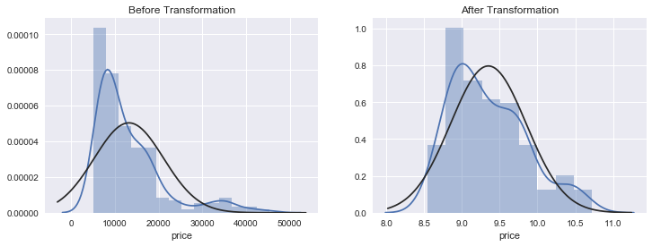

```python
fig, ax = plt.subplots(1,2, figsize=(12,4))
sns.distplot( auto["price"], fit = stats.norm, ax = ax[0] )
sns.distplot( np.log(auto["price"]), fit = stats.norm, ax = ax[1] )
ax[0].set_title("Before Transformation")
ax[1].set_title("After Transformation")
plt.show()
```

```
Log Transformation has made distribution more normal
```

## Numerical variables Distribution

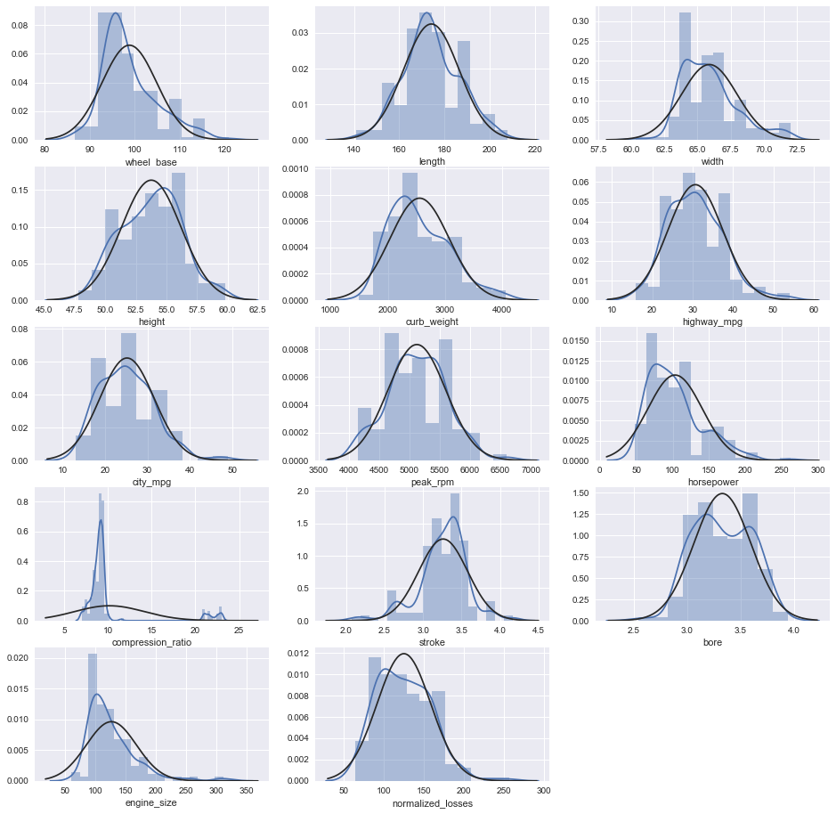

```python
fig, ax = plt.subplots(5, 3, figsize=(16,16))
ax = ax.flatten()
for i in range(len(con_var)):
    sns.distplot(auto[con_var[i]], fit = stats.norm ,ax = ax[i])
ax[-1].axis('off')
plt.show()
```

```
- length, widht, height, curb weight, highway mpg, city mpg, peak rpm , bore, normalized losses have close to normal
distribution
- rest variables dont have normal distribution
```

```python
for i in con_var:
    print("%s -- Skew : %.3f -- Kurtosis :%.3f"%(i,auto[i].skew(),auto[i].kurt()))
```

```
wheel_base -- Skew : 1.031 -- Kurtosis :0.948
length -- Skew : 0.154 -- Kurtosis :-0.065
width -- Skew : 0.875 -- Kurtosis :0.679
height -- Skew : 0.029 -- Kurtosis :-0.433
curb_weight -- Skew : 0.706 -- Kurtosis :0.035
highway_mpg -- Skew : 0.550 -- Kurtosis :0.561
city_mpg -- Skew : 0.680 -- Kurtosis :0.754
peak_rpm -- Skew : 0.088 -- Kurtosis :0.069
horsepower -- Skew : 1.155 -- Kurtosis :1.327
compression_ratio -- Skew : 2.584 -- Kurtosis :5.069
stroke -- Skew : -0.726 -- Kurtosis :2.063
bore -- Skew : -0.022 -- Kurtosis :-0.802
engine_size -- Skew : 1.979 -- Kurtosis :5.497
normalized_losses -- Skew : 0.551 -- Kurtosis :0.417
```

### Statistical significance of variables

```python
for i in con_var:
    model = sm.formula.ols("price ~"+i, data=auto).fit()
    pval = sm.stats.anova_lm(model)["PR(>F)"][0]
    #print(sm.stats.anova_lm(model))
    if pval<0.05:
        print(f"{i} -- is significant")
    #else:
    #    print(f"{i} is not significant")
```

```
wheel_base -- is significant
length -- is significant
width -- is significant
curb_weight -- is significant
highway_mpg -- is significant
city_mpg -- is significant
horsepower -- is significant
bore -- is significant
engine_size -- is significant
normalized_losses -- is significant
```

```python
final_con = ['wheel_base','length','width','curb_weight','highway_mpg','city_mpg','horsepower',
             'bore','engine_size','normalized_losses']
```

## Scatter plot with Price for variables

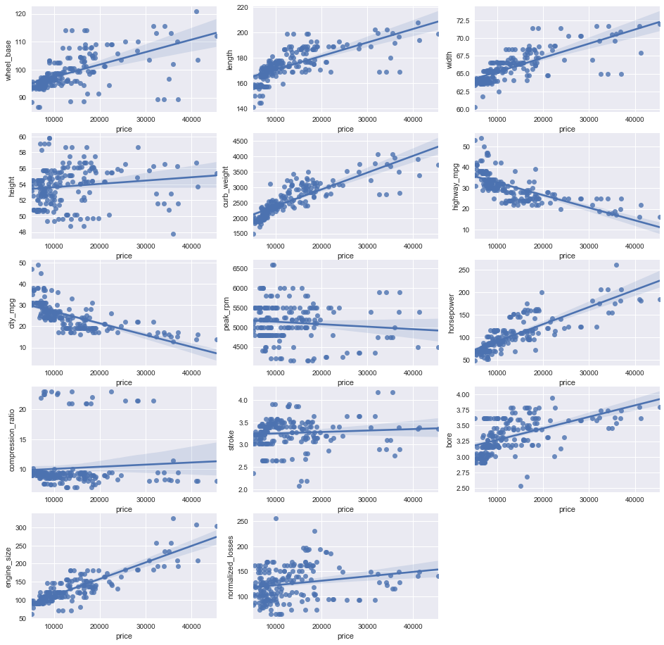

```python
fig, ax = plt.subplots(5, 3, figsize=(16,16))
ax = ax.flatten()
for i in range(len(con_var)):
    sns.regplot(y = auto[con_var[i]], x=auto["price"],ax = ax[i])
ax[-1].axis('off')
plt.show()
```

## Count Plot for categorical

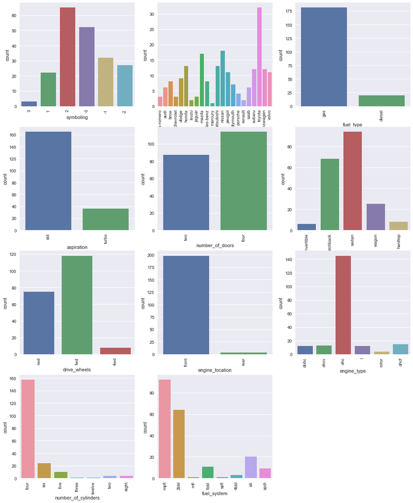

```python
fig, ax = plt.subplots(4, 3, figsize=(16,20))
ax = ax.flatten()
for i in range( len(cat_var) ):
    sns.countplot(auto[cat_var[i]],ax = ax[i])
    ax[i].set_xticklabels(labels = auto[cat_var[i]].unique(), rotation=90)
ax[-1].axis('off')
plt.show()
```

## Box Plot with Price for categorical

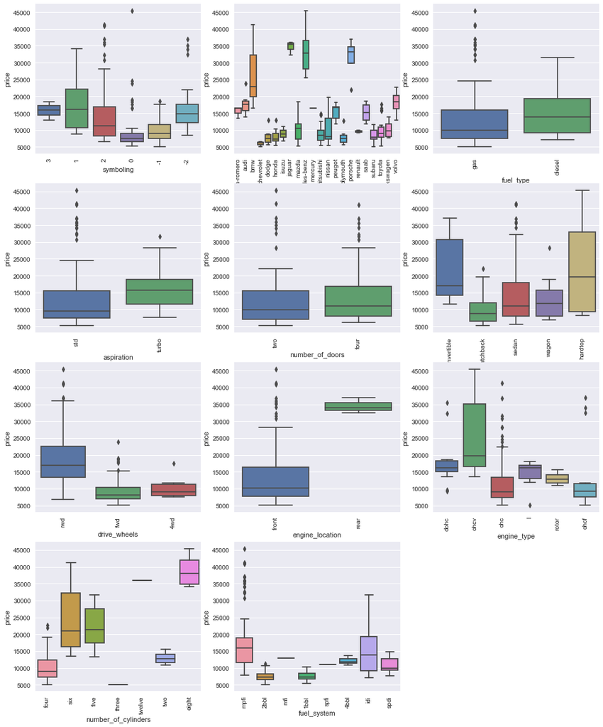

```python
fig, ax = plt.subplots(4, 3, figsize=(16,20))
ax = ax.flatten()
for i in range( len(cat_var) ):
    sns.boxplot(auto[cat_var[i]], auto["price"],ax = ax[i])
    ax[i].set_xticklabels(labels = auto[cat_var[i]].unique(), rotation=90)
ax[-1].axis('off')
plt.show()
```

### Statistical Significance of variables

```python
for i in cat_var:
    model = sm.formula.ols("price ~"+i, data=auto).fit()
    pval = sm.stats.anova_lm(model)["PR(>F)"][0]
    if pval<0.05:
        print(f"{i} -- is significant")
    #else:
    #    print(f"{i} is not significant")
```

```
make -- is significant
aspiration -- is significant
body_style -- is significant
drive_wheels -- is significant
engine_location -- is significant
engine_type -- is significant
number_of_cylinders -- is significant
fuel_system -- is significant
```

```python
final_cat = ['make','aspiration','body_style','drive_wheels','engine_location',
             'engine_type','number_of_cylinders','fuel_system']
```

# Model Evaluation Function

```python
def model_eval(model, X, Y, seed=1, flag=0):

    rs = RobustScaler()
    X = pd.DataFrame(rs.fit_transform(X), columns=X.columns)

    xtrain, xtest, ytrain, ytest = train_test_split(X, Y, train_size=0.8, random_state = seed)

    model.fit(xtrain, ytrain)
    trainpred = model.predict(xtrain)
    testpred = model.predict(xtest)

    if flag:
        check_assumption(model, xtrain, ytrain, trainpred)

    print("Training the model...\n")
    print("Train RMSE :", np.sqrt(mean_squared_error(ytrain, trainpred)) )
    print("Train R2 :", r2_score(ytrain, trainpred) )
    print("\nTest RMSE :", np.sqrt(mean_squared_error(ytest, testpred)) )
    print("Test R2 :", r2_score(ytest, testpred) )
    try:
        coeff = pd.DataFrame({'Col':X.columns, 'Coeff':model.coef_})
    except:
        coeff = pd.DataFrame({'Col':X.columns, 'Coeff':model.feature_importances_})

    coeff = coeff.sort_values('Coeff', ascending=True)

    plt.figure(figsize=(16, 5))
    plt.bar(coeff.Col, coeff.Coeff)
    plt.xticks(rotation=90)
    plt.show()
```

# Assumption Testing

```python
def check_assumption(model, x, y, pred, los= 0.05):
    print("Checking model assumptions...")

    residuals = y - pred

    from statsmodels.stats.api import het_goldfeldquandt, durbin_watson, jarque_bera, linear_rainbow, linear_harvey_collier

    print("\nChecking assumption of Homoscedasticity of residuals\n")
    _, pval, a = het_goldfeldquandt(y, x)
    if pval > los:
        print("\tThe residuals are homoscedastic")
    else:
        print("\tThe residuals do not meet this assumption, p-value:",pval)

    sns.scatterplot(np.arange(len(pred)), residuals)
    plt.title("The plot of residuals vs predicted values")
    plt.xlabel("Predicted")
    plt.ylabel("Residuals")
    plt.show()

    print("\nChecking assumption of Auto correlation of errors\n")
    r_val = durbin_watson(residuals)
    if (r_val<2.5)|(r_val>1.5) :
        print("\tThe residuals are not auto-correlated")
    else:
        print("\tThe residuals do not meet this assumption, statistic value:",r_val)
    # can make auto-correlation plot here

    print("\nChecking assumption of normality of residuals\n")
    _, pval, a, b = jarque_bera(residuals)
    if pval > los:
        print("\tThe residuals distribution is normal")
    else:
        print("\tThe residuals do not meet this assumption, p-value:", pval)

    stats.probplot(residuals, plot=plt)
    plt.show()

    print("\nChecking assumption of Linearity\n")
    #model = sm.OLS(y, x).fit()
    #_, pval = linear_rainbow(model, 0.5)
    #if pval>0.05:
    #    print("The residuals are homoscedastic")
    #else:
    #    print("The residuals do not meet this assumption")
    sns.regplot(y, pred)
    plt.title("Plot of Predicted vs Observed Values")
    plt.xlabel("Observed Values")
    plt.ylabel("Predicted Values")
    plt.show()

    print("\nChecking assumption of multicollinearity\n")
    cond = np.linalg.cond(x.values)
    print("\tThe condition number is :", cond)
    if cond> 20:
        print("\tCondition number over 20 are indication of multicollinearity")

    print("\n\n")
```

# Checking data for correlated features

```python
dummy_auto = pd.get_dummies(auto, columns = cat_var, drop_first=True)
```

#### Note : can also try make encoding using the average car price for make

```
-- this is sort of creating ranks for the cars with higher price
```

#### check results after dropping columns with mostly 0 >99 - overfit columns

```python
# can also use below method for the same
#from sklearn.feature_selection import VarianceThreshold

def overfit(data):
    overfit = []
    for i in data.columns:
        perc = (data[i]==0).sum()*100/data.shape[0]
        if perc>99:
            overfit.append(i)
    return overfit

overfit_col = overfit(dummy_auto)
print(overfit_col)
```

```
['make_isuzu', 'make_mercury', 'make_renault', 'number_of_cylinders_three', 'number_of_cylinders_twelve', 'fuel_system_mfi', 'fuel_system_spfi']
```

```python
from statsmodels.stats.outliers_influence import variance_inflation_factor as vif
#from statsmodels.graphics.api import influence_plot, interaction_plot
```

```python
X = dummy_auto.drop(["price"]+overfit_col, axis = 1)

vif_val = [vif(X.values, i) for i in range(X.shape[1])]
model_vif = pd.DataFrame(vif_val, index = X.columns, columns=['vif'])
model_vif = model_vif.sort_values("vif", ascending=False)
final_features = model_vif[(model_vif['vif']<20)].index
final_features
```

```
Index(['fuel_system_mpfi', 'fuel_system_2bbl', 'body_style_hatchback', 'width',
       'engine_type_ohc', 'drive_wheels_fwd', 'bore', 'symboling_-1',
       'body_style_wagon', 'make_mercedes-benz', 'height', 'make_volvo',
       'make_honda', 'aspiration_turbo', 'make_audi', 'make_porsche',
       'peak_rpm', 'engine_type_ohcv', 'make_mitsubishi', 'make_toyota',
       'make_bmw', 'stroke', 'make_nissan', 'fuel_system_spdi',
       'normalized_losses', 'fuel_system_4bbl', 'make_volkswagen',
       'make_jaguar', 'make_mazda', 'make_saab', 'number_of_doors_two',
       'make_dodge', 'body_style_hardtop', 'make_plymouth', 'make_chevrolet'],
      dtype='object')
```

```
Training the model...

Train RMSE : 0.1357309062360157
Train R2 : 0.9277981089019527

Test RMSE : 0.18688648817114423
Test R2 : 0.8487254057819046
```

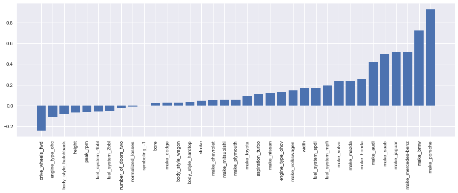

```python
X = dummy_auto[final_features]
Y = np.log(dummy_auto["price"])

model_lr = LinearRegression(n_jobs=-1)
model_eval(model_lr, X, Y)#, flag=1)    # flag = 1 to check for linear model assumptions
```

### Mutiple Linear regression without regularization

- make_porsche, make_bmw, fuel system_mpfi, fuel_system_spdi, engine_type_ohcv, aspiration_turbo, body_style_hardtop
- drive wheels, bodystyle hacthback, engine type ohc, height, number of doors two

Above are some of the variables with importance to model building

```
Training the model...

Train RMSE : 0.1358980495275829
Train R2 : 0.9276201760705132

Test RMSE : 0.1857251893250674
Test R2 : 0.8505995829644357
```

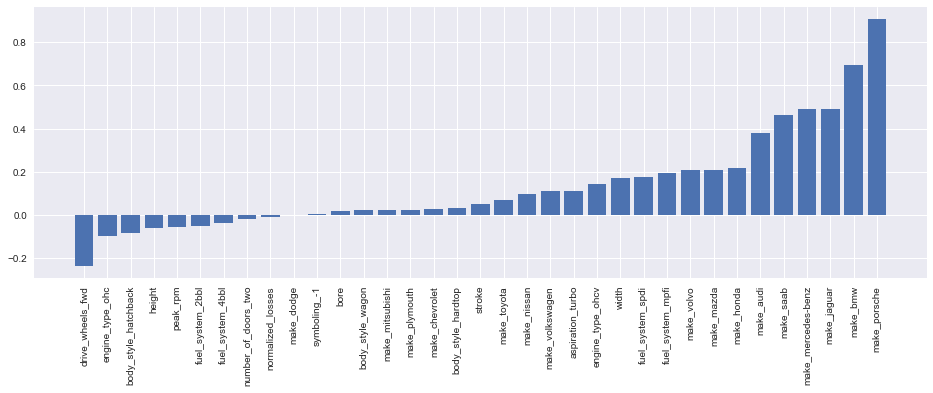

```python
X = dummy_auto[final_features]
Y = np.log(dummy_auto["price"])

model_lasso = Lasso(random_state=1, alpha=0.0001)
model_eval(model_lasso, X, Y )
```

### Mutiple Linear regression with regularization

- make_porsche, make_bmw, fuel system_mpfi, fuel_system_spdi, engine_type_ohcv, aspiration_turbo, body_style_hardtop
- drive wheels, bodystyle hacthback, engine type ohc, height, number of doors two

Above are some of the variables with importance to model building

- Lasso model applies L1 regularization which can make the coeffiecients zero for variables
- few variable coeffiecients has decreased after application of Lasso Model
- it is a stronger regularization technique than ridge

```
Training the model...

Train RMSE : 0.13573805448912313
Train R2 : 0.9277905036925372

Test RMSE : 0.1868627179889494
Test R2 : 0.8487638847112682
```

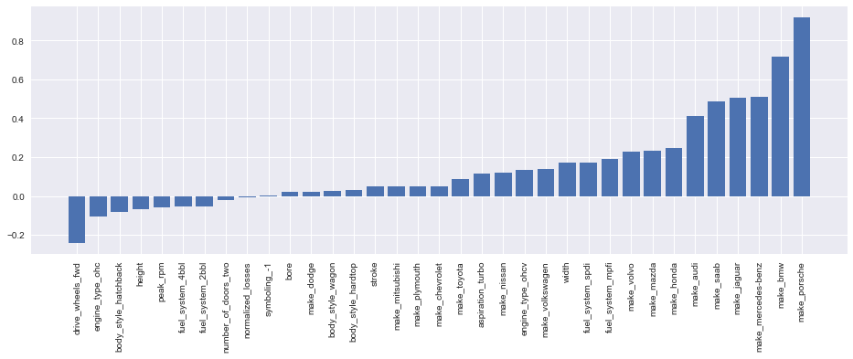

```python
X = dummy_auto[final_features]
Y = np.log(dummy_auto["price"])

model_ridge = Ridge(random_state=1, alpha=0.01)
model_eval(model_ridge, X, Y )
```

### Mutiple Linear regression with regularization

- make_porsche, make_bmw, fuel system_mpfi, fuel_system_spdi, engine_type_ohcv, aspiration_turbo, body_style_hardtop
- drive wheels, bodystyle hacthback, engine type ohc, height, number of doors two

Above are some of the variables with importance to model building

- Ridge model applies L2 regularization which can reduce the coeffiecients to near zero for variables
- few variable coeffiecients has decreased after application of Ridge Model
- it is a weaker regularization technique than lasso

```
Training the model...

Train RMSE : 0.14184887138472088
Train R2 : 0.9211425290657898

Test RMSE : 0.18243766215462676
Test R2 : 0.8558418544235705
```

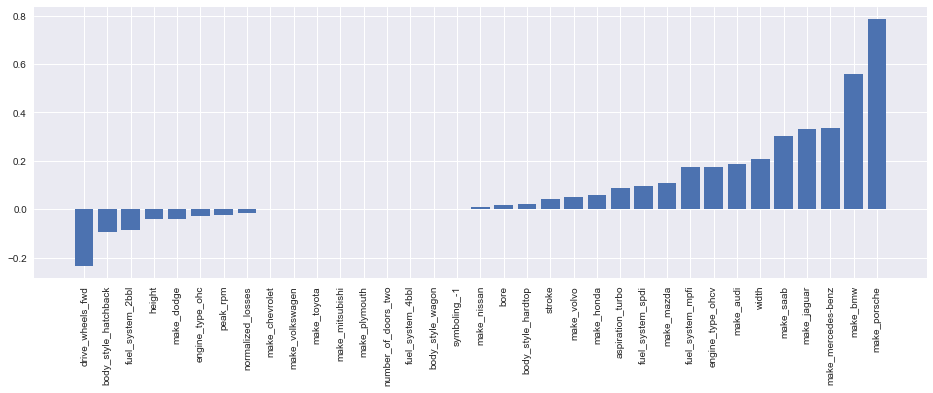

```python
X = dummy_auto[final_features]
Y = np.log(dummy_auto["price"])

model_elastic = ElasticNet(random_state=1, alpha=0.001, l1_ratio=0.99)
model_eval(model_elastic, X, Y )
```

### Mutiple Linear regression with regularization

- Elastic model combines the regularization technique from Ridge and Lasso both
- few variable coeffiecients has decreased after application of Elastic Model
- it can prove to be a better regularization technique than lasso or ridge alone